# W39 Visualization of the duration of reign among Danish monarchs through time

Hans Hermann

29/9/2023

## Get the necessary packages

I have installed the relevant package ‘tidyverse’ now applying:

```r
library(tidyverse)
```

```r
library(ggplot2)
```

## Task A

Visualize the duration of reign among Danish kings through time (showing the diachronic trend from ca 900 - today on the x axis) with ggplot. Use the dataset you/your group has created and submit both the script and the visualisation, ideally as part of an rmarkdown and html document (for details see bottom of this page). Experiment with geom_point(), geom_line() or geom_smooth() functions for the geometry.

## My solution

First i create a tibble from the dataset I have created from the earlier homework

```r
monarker <- read_csv2("data/HW2_due19-09_2_tidyversion.csv")
```

```
## ℹ Using "','" as decimal and "'.'" as grouping mark. Use `read_delim()` for more control.
```

```r
monarker
```

```
## # A tibble: 53 × 9
##    monark       født   død regent_fra regent_til regent_igen_fra regent_igen_til
##    <chr>       <dbl> <dbl>      <dbl>      <dbl>           <dbl>           <dbl>
##  1 Gorm den G…   913   958        936        958              NA              NA
##  2 Harald (1.…    NA   987        958        987              NA              NA
##  3 Svend (1.)…    NA  1014        987       1014              NA              NA
##  4 Harald (2.…    NA  1018       1014       1018              NA              NA
##  5 Knud (2.) …   995  1035       1018       1035              NA              NA
##  6 Hardeknud …  1020  1042       1035       1042              NA              NA
##  7 Magnus (1.…  1024  1047       1042       1047              NA              NA
##  8 Svend (2.)…    NA  1076       1047       1074              NA              NA
##  9 Harald (3.…    NA  1080       1074       1080              NA              NA
## 10 Knud (4.) …    NA  1086       1080       1086              NA              NA
## # ℹ 43 more rows
## # ℹ 2 more variables: regeringstid <dbl>, nr_monark <dbl>
```

I have already created a column in excel that I have called “Regeringstid”, by subtracting regent_til with regent_fra in all the rows.

If I hadn’t done that, i could create the column by using the mutate() function:

```r
# monarker %>%
#   mutate(regeringstid = regent_til - regent_fra)
```

Now for creating a visualization with bars for each monarch:

(I made a column in excel called “nr_monark” with values corresponding to the monarchs’ number in time, because I couldn’t figure out how to create it in R.)

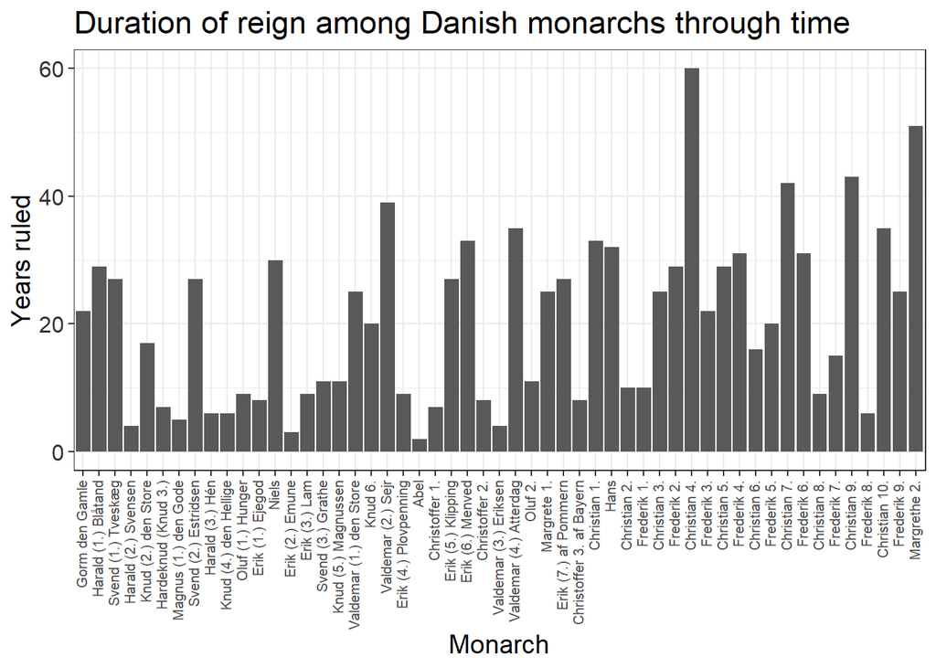

```r
monarker %>%
  ggplot(aes(x = reorder(monark, +nr_monark), y = regeringstid)) +
  geom_bar(stat = "identity") +
  geom_smooth() +
  labs(title = "Duration of reign among Danish monarchs through time",
       x = "Monarch",
       y = "Years ruled") +
  theme_bw() +
  theme(axis.text.x = element_text(size = 7.5, angle = 90, hjust = 1, vjust = 0.3),
        axis.text.y = element_text(colour = "grey20", size = 12),
        text = element_text(size = 14))
```

We can also create a trend line using geom_point() + geom_smooth() instead of geom_bar().

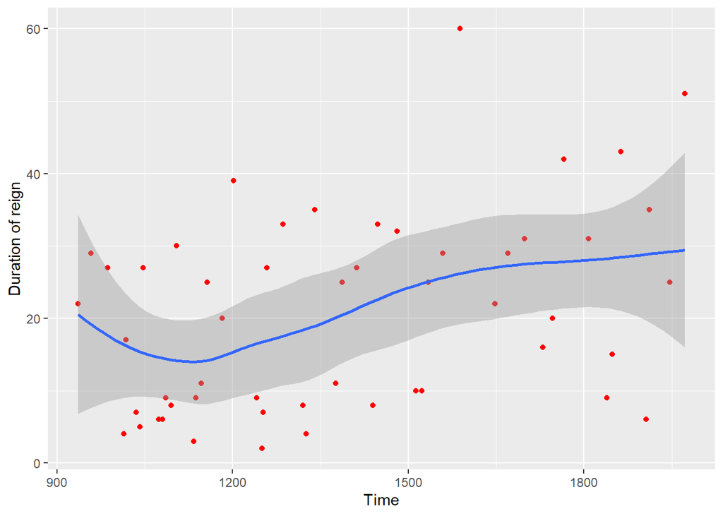

```r
monarker %>%
  ggplot(aes(x = regent_fra, y = regeringstid))+
  geom_point(color="red")+
  geom_smooth()+
  labs(x="Time",y="Duration of reign")
```